# Intro to Agent-Based Modeling (ABM) through Modeling Mass Opinion Dynamics

9 July 2019

## About This Tutorial Session

### Description

This tutorial session will demonstrate building some basic agent-based models (ABM) of population opinion dynamics in NetLogo. It will start by exploring various published opinion dynamics models (e.g. Zaller-Deffuant model). It will then continue with specific NetLogo topics such as implementing network models and extracting data from models for analysis.

### Who Should Attend?

This tutorial is aimed at two groups: 1) people who have little experience with ABM (particularly NetLogo) and would like to develop their skills with an interesting social science problem, 2) people who have some ABM experience and would like to explore a few ways of modeling opinion dynamics using ABM.

## Tutorial Materials

### NetLogo

This tutorial uses NetLogo, a popular, user-friendly, and open-source system for developing Agent Based Models. It's freely available from Northwestern University:

https://ccl.northwestern.edu/netlogo/.

### Tutorial Files

The NetLogo model files and presentation materials are available from GitHub:

https://github.com/dalefrakes/netlogo-tutorial

## Acknowledgements

I would like to thank the following for making this tutorial possible:

- SBP-BRiMS and its organizers, particularly Dr. Kathleen Carley, Dr. Nitin Argarwal, and Dr. David Broniatowski
- Dr. Wayne Wakeland, my PhD advisor at Portland State University
- Dr. William Burns, of Decision Research

## About the Presenter

Dale Frakes is a Ph.D. candidate in the Systems Science program at Portland State University, working under Dr. Wayne Wakeland. He developed and teaches a course, *Modeling & Simulation with R & Python* as well as teaching the program’s course in Agent Based Modeling. He is currently working with two academic teams applying computer modeling to research on “Fake News” and Intergenerational Obesity.

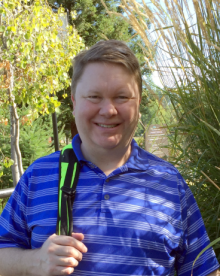

## Topics Covered in this Tutorial

- the Zaller-Deffuant model of mass opinion (and variations)
- translating mathematical statements into NetLogo code
- building models incrementally, adding complexity in successive steps (e.g. “always have a working model)
- exploring different ways of drawing random numbers from various distributions in NetLogo
- using NetLogo’s network capabilities to build network-based models
- extracting data from runs of NetLogo models for analysis in other tools (e.g. R, Python, Excel, etc.) using Behavior Space or exporting directly to CSV from model code
- comparing model code written in other languages (e.g. Fortran) with code in NetLogo
- accessing models and code stored on a Git repository

## Questions?

This is a working tutorial, so feel free to ask questions as we go.

## Agent Based Models: Key Features

- Designed from the bottom-up
- The behaviors of agents/individuals are programmed
- There can be different kinds of agents (homogeneity)
- How the agents interact with one-another is of particular interest
- Data can be collected, aggregated, and analyzed
- Considered to be “generative” (can complex behaviors arise from simple rules?)
- Can help find a “minimum required rules for a phenomena (but can’t prove these are THE rules)

## Agent-Based Modeling: Different from other Modeling

They differ from other common modeling methods that tend to be top-down (e.g. statistical models, system dynamics, discrete-event, monte-carlo, etc.)

## Intro to NetLogo

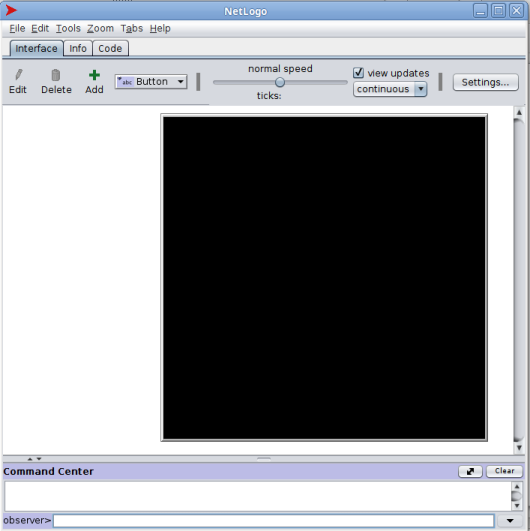

## NetLogo: Key Features

- Model Library
- Interface Tab
  - "the world"
  - adding buttons, sliders, etc.
  - speed, viewing updates
  - "command center"
  - watching turtles and patches
- Info Tab
- Code Tab

## Building Models

Now we'll work from the tutorial file.

## Last Questions?

## Thank You!

Thank you for attending this presentation. Feel free to contact me if you have any later questions: dfrakes@pdx.edu.